# R Notebook

```r
library(tidyverse)
library(ggplot2)
```

```r
districts = read_csv("./data/districts.csv")
districts
```

| system | system_name | alg_1 | alg_2 | bio | chem | ela | eng_1 | eng_2 | eng_3 | math | science | enrollment | black | hispanic | native | el | swd | ed | expenditures | act_composite | chronic_abs | suspended | expelled | grad | dropout | region |
| --- | --- | --- | --- | --- | --- | --- | --- | --- | --- | --- | --- | --- | --- | --- | --- | --- | --- | --- | --- | --- | --- | --- | --- | --- | --- | --- |
| 0 | State of Tennessee | 70.0 | 54.3 | 65.3 | 44.2 | 48.4 | 71.8 | 64.8 | 41.7 | 54.7 | 64.5 | 943699 | 24.1 | 8.5 | 0.3 | 4.6 | 14.0 | 57.9 | 9374.9 | 19.4 | 13.2 | 6.2 | 0.2 | 87.2 | 8.4 | NA |
| 10 | Anderson County | 76.1 | 63.3 | 73.6 | 41.0 | 45.7 | 73.7 | 59.2 | 38.2 | 54.0 | 64.5 | 6304 | 2.8 | 1.1 | 0.5 | 0.2 | 18.0 | 58.5 | 9535.7 | 19.9 | 11.5 | 5.0 | 0.1 | 94.0 | 4.2 | East TN |
| 11 | Clinton City | NA | NA | NA | NA | 58.3 | NA | NA | NA | 68.9 | 69.6 | 894 | 5.7 | 2.8 | 0.3 | 1.0 | 18.1 | 63.4 | 9537.5 | NA | 8.8 | 1.2 | 0.0 | NA | NA | East TN |
| 12 | Oak Ridge City | 76.9 | 72.0 | 83.5 | 80.9 | 56.1 | 86.7 | 74.6 | 53.8 | 55.3 | 70.8 | 4326 | 16.6 | 8.0 | 0.7 | 3.0 | 14.3 | 52.5 | 12355.5 | 23.1 | 17.5 | 5.7 | 0.0 | 89.7 | 4.4 | East TN |
| 20 | Bedford County | 64.3 | 42.4 | 62.1 | 32.5 | 44.1 | 72.3 | 63.1 | 44.6 | 53.1 | 61.8 | 8270 | 11.2 | 20.6 | 0.5 | 9.4 | 10.9 | 69.9 | 7756.2 | 18.4 | 8.6 | 2.2 | 0.0 | 90.8 | 5.4 | South Central |
| 30 | Benton County | 73.7 | 58.4 | 77.1 | 33.1 | 46.0 | 75.4 | 60.8 | 45.6 | 53.9 | 65.0 | 2133 | 3.9 | 2.1 | 0.3 | 0.0 | 18.8 | 50.2 | 9714.2 | 18.4 | 6.5 | 0.0 | 0.0 | 94.5 | 3.0 | Northwest |
| 40 | Bledsoe County | 64.8 | 73.9 | 73.0 | 19.5 | 35.4 | 63.6 | 53.3 | 50.0 | 41.1 | 56.2 | 1674 | 1.5 | 6.8 | 0.6 | 2.3 | 19.7 | 83.5 | 9495.9 | 19.2 | 9.1 | 2.4 | 0.1 | 92.4 | 6.9 | Upper Cumberland |
| 50 | Blount County | 73.2 | 59.8 | 65.1 | 45.4 | 46.3 | 71.8 | 66.0 | 45.3 | 50.5 | 68.4 | 10500 | 3.0 | 4.2 | 0.4 | 1.9 | 12.8 | 54.2 | 8866.9 | 19.7 | 17.0 | 4.7 | 0.1 | 89.1 | 9.2 | East TN |
| 51 | Alcoa City | 82.2 | 76.8 | 88.0 | 66.0 | 50.2 | 85.5 | 79.6 | 67.2 | 56.6 | 65.1 | 1850 | 23.3 | 9.5 | 0.6 | 2.7 | 13.0 | 49.4 | 10320.0 | 22.0 | 4.7 | 3.1 | 0.1 | 98.2 | 0.9 | East TN |
| 52 | Maryville City | 83.8 | 77.3 | 92.1 | 80.4 | 69.6 | 89.9 | 82.7 | 68.1 | 70.2 | 87.1 | 4944 | 4.2 | 4.0 | 0.2 | 2.8 | 13.2 | 32.1 | 10161.2 | 23.0 | 2.0 | 2.7 | 0.0 | 96.6 | 3.1 | East TN |

[output cut: 136 more lines]

There are 146 rows and 27 columns in districts.

Q2. Notice that the first row corresponds to the whole State of Tennessee. Remove this row and save the result back to districts.

[output not shown]

### Q3. How many districts have a proficiency rate of at least 80% for both alg_1 and eng_1?

```r
districts%>%filter(alg_1 >= 80 & eng_1 >= 80)
```

| system | system_name | alg_1 | alg_2 | bio | chem | ela | eng_1 | eng_2 | eng_3 | math | science | enrollment | black | hispanic | native | el | swd | ed | expenditures | act_composite | chronic_abs | suspended | expelled | grad | dropout | region |
| --- | --- | --- | --- | --- | --- | --- | --- | --- | --- | --- | --- | --- | --- | --- | --- | --- | --- | --- | --- | --- | --- | --- | --- | --- | --- | --- |
| 51 | Alcoa City | 82.2 | 76.8 | 88.0 | 66.0 | 50.2 | 85.5 | 79.6 | 67.2 | 56.6 | 65.1 | 1850 | 23.3 | 9.5 | 0.6 | 2.7 | 13.0 | 49.4 | 10320.0 | 22.0 | 4.7 | 3.1 | 0.1 | 98.2 | 0.9 | East TN |
| 52 | Maryville City | 83.8 | 77.3 | 92.1 | 80.4 | 69.6 | 89.9 | 82.7 | 68.1 | 70.2 | 87.1 | 4944 | 4.2 | 4.0 | 0.2 | 2.8 | 13.2 | 32.1 | 10161.2 | 23.0 | 2.0 | 2.7 | 0.0 | 96.6 | 3.1 | East TN |
| 273 | Trenton SSD | 91.6 | 84.7 | 75.6 | 64.5 | 44.6 | 82.6 | 76.0 | 50.6 | 62.9 | 53.6 | 1278 | 28.2 | 6.0 | 0.0 | 0.1 | 12.7 | 66.1 | 8916.6 | 18.6 | 10.5 | 2.8 | 0.0 | 83.5 | 11.0 | Northwest |
| 274 | Bradford SSD | 94.4 | 92.6 | 87.9 | 66.7 | 56.5 | 81.8 | 68.4 | 70.4 | 73.4 | 75.4 | 499 | 6.1 | 0.6 | 0.0 | 0.0 | 17.3 | 62.8 | 10143.5 | 18.7 | 11.4 | 0.9 | 0.0 | 100.0 | 0.0 | Northwest |
| 275 | Gibson County SSD | 83.7 | 73.2 | 75.3 | 63.0 | 57.8 | 83.8 | 73.5 | 59.6 | 67.5 | 79.7 | 3832 | 7.8 | 2.0 | 0.0 | 0.4 | 13.3 | 42.3 | 7270.0 | 19.7 | 8.2 | 0.0 | 0.0 | 94.9 | 4.0 | Northwest |
| 301 | Greeneville City | 83.2 | 90.2 | 77.7 | 86.1 | 59.3 | 87.3 | 75.1 | 66.0 | 65.5 | 74.2 | 2674 | 9.8 | 7.8 | 0.9 | 3.0 | 16.6 | 47.2 | 10862.5 | 21.3 | 9.1 | 4.5 | 0.0 | 98.6 | 0.5 | First TN |
| 390 | Henderson County | 86.0 | 88.4 | 76.4 | 53.7 | 53.3 | 81.1 | 77.7 | 51.8 | 72.1 | 71.2 | 3781 | 8.1 | 2.2 | 0.0 | 0.0 | 14.5 | 61.4 | 8412.5 | 19.5 | 10.8 | 0.0 | 0.0 | 96.4 | 2.4 | Southwest/Memphis |
| 793 | Arlington City | 88.0 | 66.9 | 82.5 | 49.8 | 75.7 | 88.8 | 78.1 | 50.7 | 75.1 | 88.3 | 4819 | 16.0 | 5.3 | 0.4 | 2.2 | 11.0 | 13.9 | 7705.1 | 21.1 | 7.9 | 2.3 | 0.1 | 94.0 | 4.4 | Southwest/Memphis |
| 795 | Collierville City | 90.2 | 85.6 | 87.4 | 80.4 | 75.1 | 92.5 | 86.2 | 66.2 | 75.7 | 86.8 | 7774 | 17.5 | 4.3 | 0.4 | 4.0 | 13.4 | 15.0 | 8383.2 | 24.0 | 5.9 | 2.8 | 0.3 | 93.0 | 2.7 | Southwest/Memphis |
| 796 | Germantown City | 90.0 | 84.2 | 88.9 | 78.5 | 79.4 | 90.8 | 87.7 | 70.8 | 74.3 | 88.0 | 5624 | 12.3 | 3.1 | 0.3 | 2.6 | 9.8 | 9.6 | 7930.8 | 24.1 | 5.1 | 1.3 | 0.0 | 88.7 | 7.9 | Southwest/Memphis |

[output cut: 3 more lines]

```r
count(districts%>%filter(alg_1 >= 80 & eng_1 >= 80))
```

| n |
| --- |
| 13 |

There are 13 districts.

### Q4. How many districts have a proficiency rate less than 50% for either alg_1 or eng_1?

```r
districts%>%filter(alg_1 < 50  | eng_1 < 50)
```

| system | system_name | alg_1 | alg_2 | bio | chem | ela | eng_1 | eng_2 | eng_3 | math | science | enrollment | black | hispanic | native | el | swd | ed | expenditures | act_composite | chronic_abs | suspended | expelled | grad | dropout | region |
| --- | --- | --- | --- | --- | --- | --- | --- | --- | --- | --- | --- | --- | --- | --- | --- | --- | --- | --- | --- | --- | --- | --- | --- | --- | --- | --- |
| 240 | Fayette County | 39.7 | 14.7 | 56.1 | 20.2 | 32.6 | 58.9 | 53.2 | 35.4 | 36.1 | 41.1 | 3220 | 58.8 | 5.0 | 0.1 | 2.3 | 13.9 | 80.6 | 9125.9 | 16.6 | 14.5 | 12.9 | 0.0 | 80.6 | 15.9 | Southwest/Memphis |
| 310 | Grundy County | 47.9 | 41.7 | 51.9 | 41.9 | 32.4 | 62.0 | 62.0 | 36.7 | 37.8 | 47.7 | 2105 | 0.2 | 1.0 | 0.1 | 0.4 | 19.0 | 81.2 | 9087.9 | 17.6 | 18.1 | 0.3 | 0.0 | 90.0 | 5.3 | Southeast |
| 410 | Hickman County | 40.2 | 22.6 | 54.2 | 45.1 | 48.9 | 60.3 | 57.5 | 31.3 | 58.1 | 68.0 | 3439 | 3.2 | 1.7 | 0.5 | 0.6 | 18.1 | 69.1 | 8965.8 | 18.4 | 17.3 | 1.6 | 0.0 | 92.5 | 5.2 | South Central |
| 440 | Jackson County | 45.9 | 33.3 | 68.9 | 50.0 | 42.8 | 61.8 | 47.3 | 46.3 | 45.3 | 64.7 | 1505 | 0.9 | 1.5 | 0.3 | 0.0 | 19.7 | 83.4 | 9165.8 | 18.4 | 8.2 | 0.0 | 0.0 | 87.4 | 8.4 | Upper Cumberland |
| 480 | Lake County | 22.9 | NA | 25.0 | 36.5 | 32.5 | 36.8 | 34.6 | 31.7 | 34.7 | 45.6 | 807 | 30.2 | 3.3 | 0.1 | 0.1 | 18.6 | 77.0 | 10813.0 | 16.4 | 31.2 | 5.5 | 0.1 | 89.4 | 6.4 | Northwest |
| 680 | Perry County | 48.5 | 50.6 | 58.0 | 19.0 | 42.6 | 60.8 | 60.6 | 35.6 | 61.8 | 66.5 | 1058 | 3.2 | 2.1 | 0.8 | 0.0 | 17.1 | 71.7 | 9212.0 | 18.0 | 24.1 | 1.5 | 0.0 | 91.9 | 7.0 | South Central |
| 963 | Tenn School for Blind | 23.1 | NA | 25.0 | NA | 6.7 | 60.0 | NA | 20.0 | NA | 10.0 | NA | 16.1 | 9.8 | 0.0 | 1.4 | 94.4 | 32.9 | NA | NA | 41.3 | 0.0 | 0.0 | 11.1 | 0.0 | Mid Cumberland |
| 985 | Achievement School District | 34.0 | 20.4 | 20.6 | NA | 14.3 | 37.8 | 33.0 | 8.2 | 23.3 | 26.1 | 6370 | 96.7 | 1.5 | 0.0 | 1.1 | 12.9 | 96.6 | 12804.4 | 14.2 | 27.2 | 21.4 | 0.1 | 54.7 | 27.6 | Southwest/Memphis |

```r
count(districts%>%filter(alg_1 < 50  | eng_1 < 50))
```

[output not shown]

There are 8 districts.

### Q5.Which district has the lowest graduation rate?

```r
districts%>%filter(grad == min(districts$grad, na.rm = TRUE))%>%
  select(system_name, grad)
```

[output not shown]

Tennessee School for Blind has the lowest graduation rate.

### Q6. Within the Mid Cumberland region, which district has the highest ACT composite?

```r
districts%>%filter(region == 'Mid Cumberland')%>%
  filter(act_composite == max(act_composite, na.rm = TRUE))%>%
  select(system_name, act_composite)
```

| system_name | act_composite |
| --- | --- |
| Williamson County | 23.8 |

### Q7. Create a histogram showing the distribution of graduation rates. What can you say about this distribution?

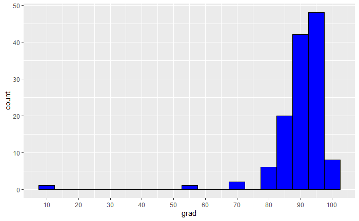

```r
ggplot(districts, aes(grad)) +
  geom_histogram(binwidth = 5, fill = 'blue', color = 'black')+
  scale_x_continuous(breaks=seq(0, 100, 10))
```

```r
NA
```

### Q8. Create a scatter plot to compare alg_1 proficiency rates to alg_2 rates. What do you notice?

### Facet this plot by region. Does anything stand out when you facet the plots?

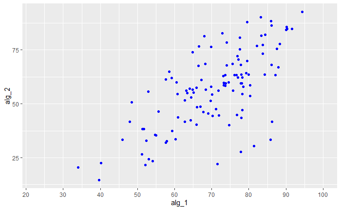

```r
ggplot(districts) +
  geom_point(aes(alg_1, alg_2), color = 'blue') +
  scale_x_continuous(breaks=seq(0, 100, 10))
```

The scatter plot shows there is a strong correlation between alg_1 and alg_2 proficiency rates.

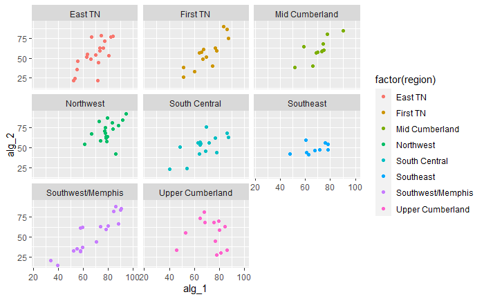

```r
ggplot(districts) +
  geom_point(aes(alg_1, alg_2, color = factor(region))) +
  facet_wrap((.~region), nrow = 3, ncol = 3)
```

### Q9. Create a bar chart showing the total enrollment by region.

### Which region has the highest total enrollment? Which has the smallest?

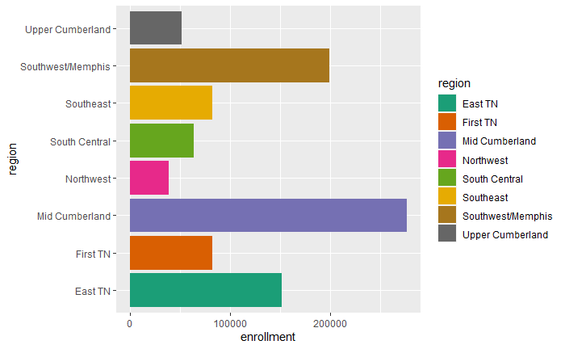

```r
options(scipen = 999)
p = ggplot(districts, aes(x=region, y=enrollment, fill = region)) +
  geom_bar(stat = "identity") +
  scale_fill_brewer(palette = "Dark2")

p + coord_flip()
```

```r
NA
NA
```

Reordering by enrollment

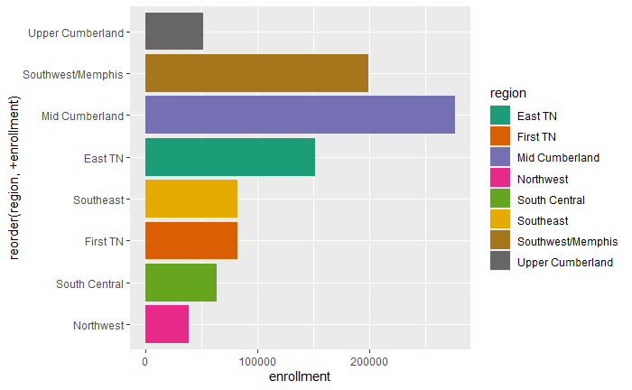

```r
options(scipen = 999)
p = ggplot(districts, aes(x = reorder(region, +enrollment), y=enrollment, fill = region)) +
  geom_bar(stat = "identity") +
  scale_fill_brewer(palette = "Dark2")

p + coord_flip()
```

upper cumberland and southwest memphis do not get in order. Mid Cumberland has the highest enrollment, Northwest has the lowest enrollment.

### Q10. When creating this bar chart you may have noticed that some districts have missing enrollment values.

### For how many districts is this the case?

```r
sum(is.na(districts$enrollment))
```

```
[1] 4
```

```r
districts%>%filter(is.na(enrollment))%>%group_by(region, system_name)%>%tally()
```

| region | system_name | n |
| --- | --- | --- |
| East TN | Tenn School for Deaf | 1 |
| Mid Cumberland | Tenn School for Blind | 1 |
| Southwest/Memphis | West Tenn School for Deaf | 1 |
| Upper Cumberland | Alvin C. York Institute | 1 |

### Q11. What is the mean graduation rate across all districts?

### What might be wrong with using just the regular mean to assess average graduation rates?

```r
mean(districts$grad, na.rm = TRUE)
```

```
[1] 90.06562
```

### Q12. Redo the previous question but use a weighted average (weighted.mean) graduation across all districts, weighing by enrollment.

### How much does this change your answer?

### Can you explain using the data the reason for the big change from using the mean?

```r
weighted.mean(districts$grad, dplyr::coalesce(districts$enrollment,0), na.rm=TRUE)
```

```
[1] 87.33285
```